# Chapter 14.3 Instruments and causal designs

Instrumental variables are “tricks” to try and get around cases where we have an otherwise impossible task given our DAG and unobserved variables.

Taking the dag below where we’re trying to find the effect of education on wages :

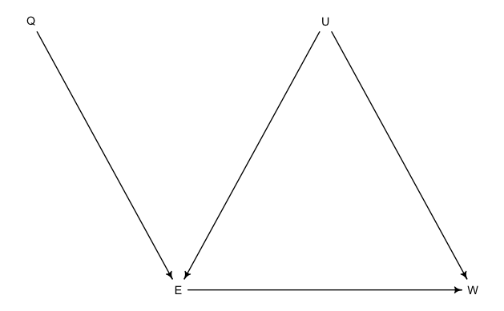

```r
dag14.1 <- dagitty("dag{Q -> E;
U -> E;
E -> W;
U -> W}")
coordinates(dag14.1) <- list(x = c(Q=0, E=1, U=2, W=3),
                               y=c(Q=0, E=1, U=0, W=1))
drawdag(dag14.1)
```

It’s as though we have performed an experiment on E. IF we regress correctly.

Some generated data:

```r
set.seed(1999)
N <- 500
U_sim <- rnorm(N)
Q_sim <- sample(1:4, size = N, replace = TRUE)
E_sim <- rnorm(N, U_sim + Q_sim)
W_sim <- rnorm(N, U_sim + 0*E_sim)
dat_sim <- list(
  W=standardize(W_sim),
  E=standardize(E_sim),
  Q=standardize(Q_sim)
)
```

Normally distributed confound. Q is the quarter of year of birth. In the states, those born in Q1 start school later and have the option to drop out earlier, hence typically have less schooling. Education E is determined by this Q and our confound U.

Here, we’ve said wages are influence by confound U but *not* education.

Naively regress wages solely on education.

```r
m14.4 <- ulam(
  alist(
    W ~ dnorm( mu, sigma),
    mu <- aW + bEW*E,
    aW ~ dnorm(0, 0.2),
    bEW ~ dnorm(0, 0.5),
    sigma ~ dexp(1)
  ), data=dat_sim, chains=4
)
```

```r
precis(m14.4)
```

|  | mean | sd | 5.5% | 94.5% | n_eff | Rhat4 |
| --- | --- | --- | --- | --- | --- | --- |
| aW | 0.00 | 0.04 | -0.07 | 0.06 | 2068 | 1 |
| bEW | 0.31 | 0.04 | 0.24 | 0.38 | 2074 | 1 |
| sigma | 0.95 | 0.03 | 0.90 | 1.00 | 2144 | 1 |

…and we see our backdoor through the confound! There’s allegedly an effect of education on wages here.

We’ve asked the golem to take a look at this data and tell us if there’s a relationship:

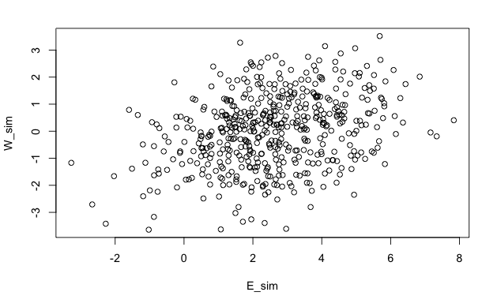

```r
plot(E_sim, W_sim)
```

and understandably given only this info, it has.

Now a new model where we simply throw everything into the mix, with our new instrument Q.

```r
m14.5 <- ulam(
  alist(
    W ~ dnorm(mu, sigma),
    mu <- aW + bEW*E + bQW*Q,
    aW ~ dnorm(0, 0.2),
    bEW ~ dnorm(0, 0.5),
    bQW ~ dnorm(0, 0.5),
    sigma ~ dexp(1)
  ), data=dat_sim, chains=4
)
```

```r
precis(m14.5)
```

|  | mean | sd | 5.5% | 94.5% | n_eff | Rhat4 |
| --- | --- | --- | --- | --- | --- | --- |
| aW | 0.00 | 0.04 | -0.06 | 0.06 | 1790 | 1 |
| bEW | 0.55 | 0.05 | 0.46 | 0.63 | 1418 | 1 |
| bQW | -0.37 | 0.05 | -0.45 | -0.29 | 1410 | 1 |
| sigma | 0.91 | 0.03 | 0.86 | 0.95 | 1737 | 1 |

This has made things even worse. There’s more of an effect of Education on Wages now, and our instrument allegedly has a negative effect on wages! This is bias amplification.

Instead, let’s try this model. We hypothesise that education and wages co-vary. Also, looking at our DAG, that wages depend on education, and education depends on instrument Q - birth quarter. Education is on both sides of the equation. This is OK.

```r
m14.6 <- ulam(
  alist(
    c(W, E) ~ multi_normal(c(muW, muE), Rho, Sigma),
    muW <- aW + bEW*E,
    muE <- aE + bQE*Q,
    c(aW, aE) ~ normal(0, 0.2),
    c(bEW, bQE) ~ normal(0, 0.5),
    Rho ~ lkj_corr(2),
    Sigma ~ exponential(1)
  ), data=dat_sim, chains = 4
)
```

```r
precis(m14.6, depth = 3)
```

|  | mean | sd | 5.5% | 94.5% | n_eff | Rhat4 |
| --- | --- | --- | --- | --- | --- | --- |
| aE | 0.00 | 0.03 | -0.05 | 0.05 | 1454 | 1 |
| aW | 0.00 | 0.05 | -0.07 | 0.07 | 1599 | 1 |
| bQE | 0.64 | 0.03 | 0.59 | 0.69 | 1314 | 1 |
| bEW | -0.02 | 0.07 | -0.13 | 0.09 | 936 | 1 |
| Rho[1,1] | 1.00 | 0.00 | 1.00 | 1.00 | NaN | NaN |
| Rho[1,2] | 0.43 | 0.06 | 0.34 | 0.52 | 810 | 1 |
| Rho[2,1] | 0.43 | 0.06 | 0.34 | 0.52 | 810 | 1 |
| Rho[2,2] | 1.00 | 0.00 | 1.00 | 1.00 | 1675 | 1 |
| Sigma[1] | 1.01 | 0.04 | 0.95 | 1.08 | 984 | 1 |
| Sigma[2] | 0.77 | 0.02 | 0.73 | 0.81 | 1781 | 1 |

Our results here show that there is very little effect of education and wages, when birth quarter is considered. The Rho[1,2] parameter is *not* the *actual* correlation between education and wages, but the residual once the effect of the instrument is taken into account.

Try with new data where we do simulate an effect of education on wages.

```r
W_sim <- rnorm(N, U_sim + 1*E_sim)
dat_sim <- list(
  W=standardize(W_sim),
  E=standardize(E_sim),
  Q=standardize(Q_sim)
)
m14.4x <- ulam(m14.4, data=dat_sim, chains=4)
m14.6x <- ulam(m14.6, data=dat_sim, chains=4)
```

```r
precis(m14.4x)
```

|  | mean | sd | 5.5% | 94.5% | n_eff | Rhat4 |
| --- | --- | --- | --- | --- | --- | --- |
| aW | 0.00 | 0.02 | -0.04 | 0.04 | 1926 | 1 |
| bEW | 0.87 | 0.02 | 0.83 | 0.90 | 2119 | 1 |
| sigma | 0.50 | 0.02 | 0.47 | 0.52 | 2145 | 1 |

```r
precis(m14.6x, depth = 3)
```

|  | mean | sd | 5.5% | 94.5% | n_eff | Rhat4 |
| --- | --- | --- | --- | --- | --- | --- |
| aE | 0.00 | 0.03 | -0.05 | 0.05 | 2014 | 1 |
| aW | 0.00 | 0.02 | -0.04 | 0.03 | 1870 | 1 |
| bQE | 0.64 | 0.03 | 0.59 | 0.69 | 1638 | 1 |
| bEW | 0.74 | 0.04 | 0.68 | 0.80 | 1274 | 1 |
| Rho[1,1] | 1.00 | 0.00 | 1.00 | 1.00 | NaN | NaN |
| Rho[1,2] | 0.32 | 0.06 | 0.22 | 0.42 | 1329 | 1 |
| Rho[2,1] | 0.32 | 0.06 | 0.22 | 0.42 | 1329 | 1 |
| Rho[2,2] | 1.00 | 0.00 | 1.00 | 1.00 | 2097 | 1 |
| Sigma[1] | 0.51 | 0.02 | 0.49 | 0.55 | 1462 | 1 |
| Sigma[2] | 0.77 | 0.03 | 0.73 | 0.81 | 1712 | 1 |

```r
NA
```

The dodgy model is more confident than it should be. The correct model shows that there now is an effect. It also shows there remains some co-variance between wages and education. Just showing there is causation is not enough, we also want to know how much.

Finally, education is positive but the confound is negative, meaning that it is hidden

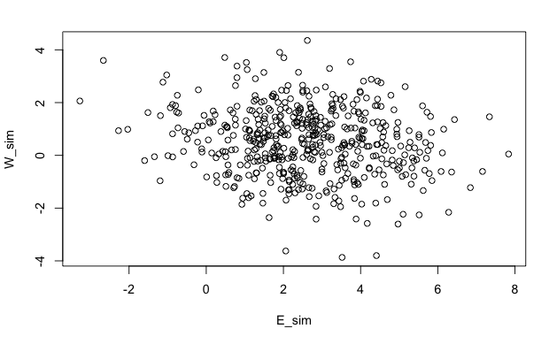

```r
W_sim <- rnorm(N, -U_sim + 0.2*E_sim)
dat_sim <- list(
  W=standardize(W_sim),
  E=standardize(E_sim),
  Q=standardize(Q_sim)
)
plot(E_sim, W_sim)
```

```r
m14.4x <- ulam(m14.4, data=dat_sim, chains=4)
m14.6x <- ulam(m14.6, data=dat_sim, chains=4)
```

```r
precis(m14.4x)
```

|  | mean | sd | 5.5% | 94.5% | n_eff | Rhat4 |
| --- | --- | --- | --- | --- | --- | --- |
| aW | 0.00 | 0.04 | -0.07 | 0.07 | 1923 | 1 |
| bEW | -0.16 | 0.04 | -0.23 | -0.09 | 1572 | 1 |
| sigma | 0.99 | 0.03 | 0.94 | 1.03 | 1765 | 1 |

```r
precis(m14.6x, depth = 3)
```

|  | mean | sd | 5.5% | 94.5% | n_eff | Rhat4 |
| --- | --- | --- | --- | --- | --- | --- |
| aE | 0.00 | 0.03 | -0.06 | 0.06 | 1181 | 1.00 |
| aW | 0.00 | 0.05 | -0.07 | 0.07 | 1235 | 1.00 |
| bQE | 0.64 | 0.03 | 0.59 | 0.70 | 1505 | 1.00 |
| bEW | 0.20 | 0.07 | 0.09 | 0.32 | 870 | 1.01 |
| Rho[1,1] | 1.00 | 0.00 | 1.00 | 1.00 | NaN | NaN |
| Rho[1,2] | -0.45 | 0.05 | -0.53 | -0.36 | 993 | 1.01 |
| Rho[2,1] | -0.45 | 0.05 | -0.53 | -0.36 | 993 | 1.01 |
| Rho[2,2] | 1.00 | 0.00 | 1.00 | 1.00 | 2191 | 1.00 |
| Sigma[1] | 1.06 | 0.04 | 0.99 | 1.13 | 1288 | 1.01 |
| Sigma[2] | 0.77 | 0.02 | 0.73 | 0.81 | 1616 | 1.00 |

Now, the model gives us the inferrence that there is a correlation between Education and Wages (as we simulated) but a negative residual correlation between them (Rho[1,2]) indicating that the unobserved confound affects them in different directions.

Incorrect model gives us the wrong inference, as it would do given all the info we’ve given it is that scatter plot.

Instruments can be hard to find. They might also not be that strong. Can be effective though.